# Optimization final project

Kenwan Cheung, Joan Lee, Chantel Miller, Anthony Smaniotto.

### Background:

As computing power and data size have grown exponentially in the past decade there has been a massive improvement in the accuracy and complexity of neural networks. While theorized by Minksy and others in the 60s, it was the breakthrough in the early 1980s by Geoffrey Hinton and his co-authors with the development of “back-propogation” that enabled development of deeper networks. When combined with the improvements in raw computing power and scale of data, we’ve seen neural networks become proficient at a variety of tasks, from image recognition to beating the best human players in the game of Go.

### Problem:

As neural networks have gotten deeper and more complex, parameter estimation and the relevant optimization methodology is now a critical step to building neural networks.

At a simple level, neural networks could be thought of as a host of regressions set up in m-layers. We must figure out the weights of each one of those connections. In the simple example below with just one set of hidden layers, The number of parameters to be estimated is calculated by the sum of the product of the numbers of nodes in connected layers. Parameters: (3×4)+(4×2)=20.

We can intuitively see how quickly the parameter estimation process grows. Many of the advances in the past decade have come hand in hand with advances in the optimization methods used to optimize the parameter estimation and improve time to convergence.

### Our goal:

Our team will seek to hand-code neural networks while implementing several of the most common optimization methods such as: stochastic gradient descent, Adagrad, ADAM. We will seek to gain a deeper understanding over how they converge by leveraging the age old Francisco™ method: simulation, development of our own functions, and visualization. We will complete this in Python.

```python
# IMPORT PACKAGES

# Import relevant packages

%matplotlib inline
from sklearn import datasets, neighbors
import numpy as np
import pandas as pd
import matplotlib.pyplot as plt
import seaborn as sns
from sklearn.model_selection import cross_val_score, GridSearchCV,KFold, RandomizedSearchCV
from sklearn.metrics import confusion_matrix, accuracy_score, classification_report, roc_curve, roc_auc_score
from sklearn.cross_validation import train_test_split
from sklearn.ensemble import RandomForestClassifier, GradientBoostingClassifier
from sklearn.neighbors import KNeighborsClassifier
from sklearn.preprocessing import OneHotEncoder
from imutils import paths
from keras.models import Sequential
from keras.layers import Input, Dropout, Flatten, Convolution2D, MaxPooling2D, Dense, Activation, Conv2D, ZeroPadding2D
from keras.optimizers import RMSprop, adam
from keras.callbacks import ModelCheckpoint, Callback, EarlyStopping
from keras.utils import np_utils,to_categorical
from keras.preprocessing.image import ImageDataGenerator, array_to_img, img_to_array, load_img
from keras import backend as K
from keras.metrics import binary_accuracy,binary_crossentropy
from tqdm import tqdm
from IPython.display import SVG
from keras.utils.vis_utils import model_to_dot
from keras.regularizers import l2 # L2-regularisation
from keras.layers.normalization import BatchNormalization # batch normalisation
from sklearn import svm
import random
import argparse
import datetime
import imutils
import cv2
import os
import re
import shutil
from IPython.display import Image
K.set_image_dim_ordering('th')
```

# Part 1

Simulation of the dataset.

Let's begin by simulating a simple data generation process.

Let's simulate a multivariate normal distribution. We might use a logistic regression in this scenario.

```python
# set seed
np.random.seed(12)
n = 10000

x_1 = np.random.multivariate_normal([0, 0], [[1, .75],[.75, 1]], n)
x_2 = np.random.multivariate_normal([1, 4], [[2, .75],[.75, 2]], n)
x_3 = np.random.multivariate_normal([2, 8], [[3, .75],[.75, 3]], n)

simulated_separableish_features = np.vstack((x_1, x_2, x_3)).astype(np.float32)
y = np.hstack((np.zeros(n),
               np.ones(n),
              np.ones(n)+1))
```

```python
print(x_1.shape,x_2.shape,x_3.shape)
print(y.shape)
```

```
(10000, 2) (10000, 2) (10000, 2)
(30000,)
```

```
Text(0.5,1,'simulated data multivariate')
```

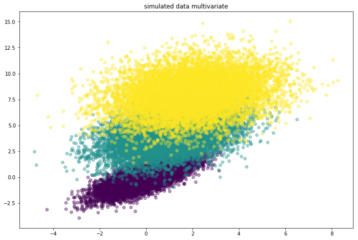

```python
plt.figure(figsize=(12,8))
plt.scatter(simulated_separableish_features[:, 0], simulated_separableish_features[:, 1],
            c = y, alpha = .4)
plt.title("simulated data multivariate")
```

# Part 2

Let's begin by setting up a function for a small NN.

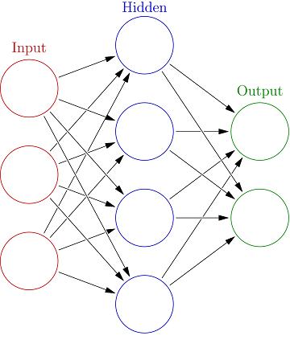

```python
Image("../optimization_final/raw/neural_network_hidden.png")
```

### Discussion of how to build a neural net.

Neural nets at their core are typically built around sigmoid functions. The biggest discrepancy with a more traditional approach would be the rise of "hidden" layers whose weights we are trying to calculate.

```
1) Input layer weights - just like we would for a logistic regression.
2) We develop a hidden layer around some "activation function". Originally these were sigmoid functions, but advancements have been made to move away from the sigmoid (how our own neurons work), to something like the ReLu.
3) Go from hidden layer to outputs layer.
4) Translate output layer to output values with a probability distribution. Typically softmax.
```

In a traditional logistic regression, the optimization occurs around the log-likelihood, which we try and maximize given a series of coefficients.

#### Log-Likelihood optimization

$ll = \sum_{i=1}^N y_i\beta^Tx_i - log(1+e^{\beta^Tx_i})$

#### Neural network optimization

We can think about neural nets as something similar. We must optimize the errors around a particular set of weights for each layer. We do this iteratively until we reach some threshold of tolerance.

# Building our networks

In order for us to build our network, we'll need several things:

```
1) initialize arrays with the correct size.
2) set up an activation fx
3) set up a output function
4) set up a loss function
5) set up back propogation / gradient passing to allow the network to adjust the next iteration. In a sense we're calculating the error as each coefficient changes. Or the derivative of the error with respect to a given weight.
```

### Setting up the shape of our arrays

We need to ensure our matrices line up! We need to do the following matrix multiplications:

```
1) We start with random weights * input of shape (n * features)
2) So our weights array must have shape of (features * hidden nodes)
3) Bias term has shape of (1, number of hidden nodes)
```

Next layer for hidden.

```
4) weights now must be of shape (hidden nodes * num_labels)
5) bias term is now (1, # of labels)
```

```python
hidden_nodes = 5
num_features = 2
num_labels = 3
```

```python
layer1_weights_array = np.random.normal(0, 1, [num_features, hidden_nodes])
layer1_biases_array = np.zeros((1, hidden_nodes))

layer2_weights_array = np.random.normal(0, 1, [hidden_nodes, num_labels])
layer2_biases_array = np.zeros((1, num_labels))
```

### Activation fx

Original nets modeled their construction on a sigmoid after finding that is how our own physiology was designed. However, mnewer work has come on modified sigmoid fx that help to speed up convergence.

In this case ReLu (rectified linear unit) has a value of 0 and then a linear increase past 0, which helps dead neurons to stay dead, and speed up how quickly we find optimal weights

$f(x)=x^{+}=\max(0,x)$

```python
def relu_activation(data_array):
    return np.maximum(data_array, 0)
```

### Softmax - from output layer to output itself.

The softmax allows us to transform a given output layer to an actual distribution, and corresponding output classification.

$\sigma (\mathbf {z} )_{j}={\frac {e^{z_{j}}}{\sum _{k=1}^{K}e^{z_{k}}}} for j = 1, …, K $

```python
def softmax(output_array):
    logits_exp = np.exp(output_array)
    return logits_exp / np.sum(logits_exp, axis = 1, keepdims=True)
```

### Loss function

We need some way to evaluate each series of estimates. We will use cross entropy given we're looking at a classification issue and want some binary decision rather than that of a squared distance metric.

$H(p,q)=-\sum _{x}p(x)\,\log q(x)$

```python
def cross_entropy_softmax_loss_array(softmax_probs_array, y_onehot):
    indices = np.argmax(y_onehot, axis = 1).astype(int)
    predicted_probability = softmax_probs_array[np.arange(len(softmax_probs_array)), indices]
    log_preds = np.log(predicted_probability)
    loss = -1.0 * np.sum(log_preds) / len(log_preds)
    return loss
```

### Regularization

While not necessary, this step also helps to prevent overfitting. We'll also implement some additional overfit steps in the later steps.

```python
def regularization_L2_softmax_loss(reg_lambda, weight1, weight2):
    weight1_loss = 0.5 * reg_lambda * np.sum(weight1 * weight1)
    weight2_loss = 0.5 * reg_lambda * np.sum(weight2 * weight2)
    return weight1_loss + weight2_loss
```

### Back propagation

For EACH layer, we are looking to see the error gradient with respect to the previous.

So, the error gradient for layer2_weights_array would be the hidden_layer values times the error signal of the softmaxed output_layer.

Hinton et al. established that the error signal at the end of a given layer is the matrix multiplication of the error signal from the next layer in the network (say the output layer in layer2_weights_array) and the transpose of the weights coming out of the current layer (hidden layer).

This is then multiplied by the derivative of the layer’s activation function (relu).

```python
# # Allows us to calculate the loss at a given layer
# output_error_signal = (output_probs - labels_onehot) / output_probs.shape[0]

# # derivative of activation function from above.
# error_signal_hidden = np.dot(output_error_signal, layer2_weights_array.T)
# error_signal_hidden[hidden_layer <= 0] = 0

# # updated gradient
# gradient_layer2_weights = np.dot(hidden_layer.T, output_error_signal)
# gradient_layer2_bias = np.sum(output_error_signal, axis = 0, keepdims = True)

# # now flow through to layer 1
# gradient_layer1_weights = np.dot(data.T, error_signal_hidden)
# gradient_layer1_bias = np.sum(error_signal_hidden, axis = 0, keepdims = True)

# # regularization.
# reg_lambda = .01
# learning_rate = .01

# gradient_layer2_weights += reg_lambda * layer2_weights_array
# gradient_layer1_weights += reg_lambda * layer1_weights_array

# layer1_weights_array -= learning_rate * gradient_layer1_weights
# layer1_biases_array -= learning_rate * gradient_layer1_bias
# layer2_weights_array -= learning_rate * gradient_layer2_weights
# layer2_biases_array -= learning_rate * gradient_layer2_bias
```

```python
# accuracy
def accuracy(predictions, labels):
    preds_correct_boolean =  np.argmax(predictions, 1) == np.argmax(labels, 1)
    correct_predictions = np.sum(preds_correct_boolean)
    accuracy = 100.0 * correct_predictions / predictions.shape[0]
    return accuracy
```

# Now coding up the exact algorithm

First let's segment our data into train and test.

```python
X_train, X_test, y_train, y_test = train_test_split(simulated_separableish_features, y, test_size=0.2, random_state=42)
```

```python
y_train
```

```
array([2., 0., 2., ..., 0., 1., 2.])
```

```python
y_train_enc = to_categorical(y_train)
y_test_enc = to_categorical(y_test)
```

```python
hidden_nodes = 5
num_labels = 3
num_features = X_train.shape[1]
learning_rate = .01
reg_lambda = .01

# Weights and Bias Arrays
layer1_weights_array = np.random.normal(0, 1, [num_features, hidden_nodes])
layer2_weights_array = np.random.normal(0, 1, [hidden_nodes, num_labels])

layer1_biases_array = np.zeros((1, hidden_nodes))
layer2_biases_array = np.zeros((1, num_labels))

for step in range(0,n+1):

    input_layer = np.dot(X_train, layer1_weights_array)
    hidden_layer = relu_activation(input_layer + layer1_biases_array)
    output_layer = np.dot(hidden_layer, layer2_weights_array) + layer2_biases_array
    output_probs = softmax(output_layer)

    loss = cross_entropy_softmax_loss_array(output_probs, y_train_enc)
    loss += regularization_L2_softmax_loss(reg_lambda, layer1_weights_array, layer2_weights_array)

    output_error_signal = (output_probs - y_train_enc) / output_probs.shape[0]

    error_signal_hidden = np.dot(output_error_signal, layer2_weights_array.T)
    error_signal_hidden[hidden_layer <= 0] = 0

    gradient_layer2_weights = np.dot(hidden_layer.T, output_error_signal)
    gradient_layer2_bias = np.sum(output_error_signal, axis = 0, keepdims = True)

    gradient_layer1_weights = np.dot(X_train.T, error_signal_hidden)
    gradient_layer1_bias = np.sum(error_signal_hidden, axis = 0, keepdims = True)

    gradient_layer2_weights += reg_lambda * layer2_weights_array
    gradient_layer1_weights += reg_lambda * layer1_weights_array

    layer1_weights_array -= learning_rate * gradient_layer1_weights
    layer1_biases_array -= learning_rate * gradient_layer1_bias
    layer2_weights_array -= learning_rate * gradient_layer2_weights
    layer2_biases_array -= learning_rate * gradient_layer2_bias

    if step % 500 == 0:
            print('Loss at step {0}: {1}'.format(step, loss))
```

```
Loss at step 0: 3.3348670782375534
Loss at step 500: 0.6267423653342787
Loss at step 1000: 0.5140397316527098
Loss at step 1500: 0.44250050733107077
Loss at step 2000: 0.38778866128783585
Loss at step 2500: 0.3503542927446768
Loss at step 3000: 0.33085995102967797
Loss at step 3500: 0.31970805293714477
Loss at step 4000: 0.3123717521638662
Loss at step 4500: 0.3070512396782161
Loss at step 5000: 0.3029439130835972
Loss at step 5500: 0.29961617672193624
Loss at step 6000: 0.2968340926309012
Loss at step 6500: 0.2944621250424419
Loss at step 7000: 0.2924088329700157
Loss at step 7500: 0.2906157666389113
Loss at step 8000: 0.28904894425541167
Loss at step 8500: 0.287660998225247
Loss at step 9000: 0.2864189065845327
Loss at step 9500: 0.28529935628517145
Loss at step 10000: 0.284285070791275
```

### Shape of some outputs

```python
output_probs
```

```
array([[9.99961791e-01, 9.33520140e-10, 3.82081887e-05],
       [5.02761600e-02, 9.07468907e-01, 4.22549327e-02],
       [9.98632042e-01, 1.39946056e-06, 1.36655872e-03],
       ...,
       [4.61770445e-01, 2.18137577e-01, 3.20091978e-01],
       [9.71012105e-01, 3.16732582e-03, 2.58205694e-02],
       [9.96918486e-01, 9.25705600e-06, 3.07225656e-03]])
```

```python
loss
```

[output not shown]

```python
output_error_signal
```

```
array([[ 4.16650746e-05,  3.88966725e-14, -4.16650747e-05],
       [-3.95718267e-05,  3.78112045e-05,  1.76062219e-06],
       [ 4.16096684e-05,  5.83108568e-11, -4.16097267e-05],
       ...,
       [-2.24262315e-05,  9.08906570e-06,  1.33371658e-05],
       [ 4.04588377e-05, -4.15346948e-05,  1.07585706e-06],
       [ 4.15382703e-05,  3.85710666e-10, -4.15386560e-05]])
```

```python
error_signal_hidden
```

```
array([[ 0.00000000e+00,  4.59616589e-05,  0.00000000e+00,
         0.00000000e+00,  0.00000000e+00],
       [ 6.01788039e-05,  0.00000000e+00, -4.70887622e-05,
         3.21973065e-05,  2.02456517e-05],
       [ 0.00000000e+00,  4.59004720e-05,  0.00000000e+00,
         0.00000000e+00,  0.00000000e+00],
       ...,
       [ 0.00000000e+00, -3.52059705e-05,  0.00000000e+00,
         0.00000000e+00,  9.29926235e-06],
       [ 0.00000000e+00,  9.24629992e-05,  0.00000000e+00,
        -3.53507661e-05,  0.00000000e+00],
       [ 0.00000000e+00,  4.58213341e-05,  0.00000000e+00,
        -2.37009889e-07,  0.00000000e+00]])
```

```python
gradient_layer1_weights
```

```
array([[-0.15511026,  1.44215762,  0.10960443, -0.05276531, -0.0125284 ],
       [-0.18132447,  5.84183727,  0.12994956, -0.43064741, -0.06631487]])
```

```python
layer1_weights_array
```

```
array([[-0.32905571, -0.03652541,  0.04274017, -0.90422109,  1.01835406],
       [-1.06384745,  0.82186452, -0.79192465,  0.10858576, -1.55493711]])
```

# Predictions

```python
input_layer = np.dot(X_test, layer1_weights_array)
hidden_layer = relu_activation(input_layer + layer1_biases_array)
scores = np.dot(hidden_layer, layer2_weights_array) + layer2_biases_array
probs = softmax(scores)
print('Test accuracy: {0}%'.format(accuracy(probs, y_test_enc)))
```

```
Test accuracy: 90.95%
```

### Plot of predictions

Let's compare results.

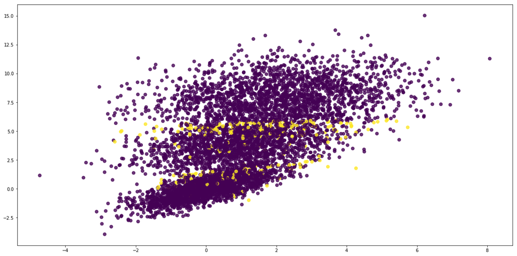

```python
labels_flat = np.argmax(y_test_enc, axis = 1)
predictions = np.argmax(probs, axis = 1)
plt.figure(figsize = (20, 10))
plt.scatter(X_test[:, 0], X_test[:, 1], c = predictions == labels_flat - 1, alpha = .8, s = 50)
```